# Getting started with CEAS

## Setup

```r
library(ceas)
```

## Importing Seahorse rates data

The read_data function imports a list of Wave excel export file(s), meaning it will import all `.xlsx` files from a common directory. With that, the user should organize the file(s) they wish to analyze in a single directory (folder). This directory can also contain the normalization CSV file (see Normalization). An easy way to get such a list is to put all your data in a directory and list its contents. For example, if your data is in a directory called “seahorse_data”:

```r
rep_list <- list.files("seahorse_data", pattern = "*.xlsx", full.names = TRUE)
```

In this vignette we use the package’s internal datasets:

```r
rep_list <- system.file("extdata", package = "ceas") |>
  list.files(pattern = "*.xlsx", full.names = TRUE)
raw_data <- readxl::read_excel(rep_list[1], sheet = 2)
knitr::kable(head(raw_data))
```

| Measurement | Well | Group | Time | OCR | ECAR | PER |
| --- | --- | --- | --- | --- | --- | --- |
| 1 | A01 | Background | 1.304765 | 0.0000 | 0.00000 | 0.0000 |
| 1 | A02 | Group_1 MITO | 1.304765 | 305.2426 | 30.64529 | 334.4771 |
| 1 | A03 | Group_1 MITO | 1.304765 | 307.9862 | 33.27668 | 358.4754 |
| 1 | A04 | Group_2 MITO | 1.304765 | 339.3399 | 49.17751 | 503.4910 |
| 1 | A05 | Group_2 MITO | 1.304765 | 321.9398 | 47.94602 | 492.2597 |
| 1 | A06 | Group_2 MITO | 1.304765 | 323.7962 | 46.84232 | 482.1940 |

- name their wells according to the *ceas* format on the Wave software or
- manually rename each Group in the Wave excel output before importing via `read_data.` If you already have the data, this column will have to be converted to this format to work with *ceas*.

```r
seahorse_rates <- read_data(rep_list)
knitr::kable(head(seahorse_rates))
```

| Measurement | Well | Time | OCR | ECAR | PER | exp_group | assay_type | replicate |
| --- | --- | --- | --- | --- | --- | --- | --- | --- |
| 1 | A01 | 1.304765 | 0.0000 | 0.00000 | 0.0000 | Background | NA | 1 |
| 1 | A02 | 1.304765 | 305.2426 | 30.64529 | 334.4771 | Group_1 | MITO | 1 |
| 1 | A03 | 1.304765 | 307.9862 | 33.27668 | 358.4754 | Group_1 | MITO | 1 |
| 1 | A04 | 1.304765 | 339.3399 | 49.17751 | 503.4910 | Group_2 | MITO | 1 |
| 1 | A05 | 1.304765 | 321.9398 | 47.94602 | 492.2597 | Group_2 | MITO | 1 |
| 1 | A06 | 1.304765 | 323.7962 | 46.84232 | 482.1940 | Group_2 | MITO | 1 |

### Normalization

There are two types of normalization involved in Seahorse data analysis. The first type of normalization is background normalization, which is typically performed within in the Seahorse Wave software. If the Seahorse data has been background normalized, the “Background” wells should have OCR and ECAR values of 0. *ceas* will flag the user with a warning if the “Background” OCR and ECAR values are not 0 (see first row of the table above).

The second type of normalization is sample normalization, which can be performed using *ceas*. Example sample normalization measures include cell count per well and $\mu$g of protein per well. Sample normalization using *ceas* requires an additional CSV file containing two columns:

1. `"exp_group"` or `"well"`
2. experimental measure values (e.g. cell counts) in this format:

```r
norm_csv <- system.file("extdata", package = "ceas") |>
  list.files(pattern = "norm.csv", full.names = TRUE)
norm_csv
```

```
#> [1] "/tmp/RtmpCnhSrf/Rinst3da5af21fb2226/ceas/extdata/norm.csv"
#> [2] "/tmp/RtmpCnhSrf/Rinst3da5af21fb2226/ceas/extdata/well_norm.csv"
```

```r
exp_group_norm <- norm_csv[1]
well_norm <- norm_csv[2]

read.csv(exp_group_norm) |>
    knitr::kable(caption = "For normalizing by experimental group")
```

For normalizing by experimental group

| exp_group | measure |
| --- | --- |
| Group_1 | 30000 |
| Group_2 | 30000 |
| Group_3 | 5000 |
| Group_4 | 5000 |

```r
read.csv(well_norm) |> head() |>
    knitr::kable(caption = "For normalizing by well")
```

For normalizing by well

| Well | measure |
| --- | --- |
| A01 | 0 |
| A02 | 5000 |
| A03 | 5500 |
| A04 | 5300 |
| A05 | 4500 |
| A06 | 5900 |

For sample normalization *ceas* can use one of two normalizing methods according to the provided `norm_method` argument:

- `"self"`: for each experimental group or well, the rows of the Seahorse data are divided by the corresponding `measure` value. Each OCR, ECAR, and PER value is divided by the measure it”self”. OCR and ECAR values are divided by the corresponding raw value in the “measure” column. This can be thought of as an intra-well/experimental group normalization. Each normalized value is then interpreted as pmol/min per cell or pmol/min per g of protein.
- `"minimum"`: When set to `"minimum"`, each OCR, ECAR, and PER value is normalized by the minimum value in the `norm_csv` “measure” column. In this method, every “measure” column’s value in the provided CSV file is divided by the lowest of the “measure” values to get a normalization factor for each well or experimental group. The OCR, ECAR, and PER values in each well or experimental group are divided by their corresponding normalization factors. Compared to `"self"`, this can be thought of as an inter-well/experimental group normalization based on the lowest `"measure"`. The results may be interpreted as pmol/min per minimum of the group cell count or g of protein.

Your normalization CSV file path may be passed into `read_data()` using the `norm` argument along with `norm_column` with either `"exp_group"` or `"well"` and `norm_method` as either `"self"` or `"minimum"`.

**Note**: it is important to minimize sample variability during your Seahorse experiment.

```r
read_data(
    rep_list,
    norm = exp_group_norm,
    norm_column = "exp_group",
    norm_method = "self"
) |> head() |> knitr::kable()
```

| Measurement | Well | Time | OCR | ECAR | PER | exp_group | assay_type | replicate |
| --- | --- | --- | --- | --- | --- | --- | --- | --- |
| 1 | A01 | 1.304765 | 0.0000000 | 0.0000000 | 0.0000000 | Background | NA | 1 |
| 1 | A02 | 1.304765 | 0.0101748 | 0.0010215 | 0.0111492 | Group_1 | MITO | 1 |
| 1 | A03 | 1.304765 | 0.0102662 | 0.0011092 | 0.0119492 | Group_1 | MITO | 1 |
| 1 | A04 | 1.304765 | 0.0113113 | 0.0016393 | 0.0167830 | Group_2 | MITO | 1 |
| 1 | A05 | 1.304765 | 0.0107313 | 0.0015982 | 0.0164087 | Group_2 | MITO | 1 |
| 1 | A06 | 1.304765 | 0.0107932 | 0.0015614 | 0.0160731 | Group_2 | MITO | 1 |

## Calculating energetics

### Partitioning data

**Note:**  
When we use the term ‘max’ in the package documentation we mean the maximal experimental OCR and ECAR values rather than absolute biological maximums.

The energetics calculation workflow involves partitioning the data into its time point and assay intervals.

```r
partitioned_data <- partition_data(seahorse_rates)
```

#### Alternative data formats

The default `partition_data()` parameters are set to analyze (1) Mito Stress Test and (2) Glycolysis Stress Test assays run in parallel in the same experiment. The `assay_types` list parameter can be modified to account for alternative experiments (e.g. just a Mito Stress Test assay).

##### Mito + Glyco (our default)

```r
partitioned_data <- partition_data(
  seahorse_rates,
  assay_types = list(
    basal = "MITO",
    uncoupled = "MITO",
    maxresp = "MITO",
    nonmito = "MITO",
    no_glucose_glyc = "GLYCO",
    glucose_glyc = "GLYCO",
    max_glyc = "GLYCO"
  ),
  basal_tp = 3,
  uncoupled_tp = 6,
  maxresp_tp = 8,
  nonmito_tp = 12,
  no_glucose_glyc_tp = 3,
  glucose_glyc_tp = 6,
  max_glyc_tp = 8
)
```

##### Data in the form of Mookerjee et al. (2017)

```r
partitioned_data <- partition_data(
  seahorse_rates,
  assay_types = list(
    basal = "RefAssay",
    uncoupled = "RefAssay",
    maxresp = NA,
    nonmito = "RefAssay",
    no_glucose_glyc = "RefAssay",
    glucose_glyc = "RefAssay",
    max_glyc = NA
  ),
  basal_tp = 5,
  uncoupled_tp = 10,
  nonmito_tp = 12,
  maxresp = NA,
  no_glucose_glyc_tp = 1,
  glucose_glyc_tp = 5,
  max_glyc = NA
)
```

##### Just Mito

```r
partitioned_data <- partition_data(
  seahorse_rates,
  assay_types = list(
    basal = "MITO",
    uncoupled = "MITO",
    maxresp = "MITO",
    nonmito = "MITO",
    no_glucose_glyc = NA,
    glucose_glyc = "MITO",
    max_glyc = NA
  ),
  basal_tp = 3,
  uncoupled_tp = 6,
  maxresp_tp = 8,
  nonmito_tp = 12,
  no_glucose_glyc_tp = NA,
  glucose_glyc_tp = 3,
  max_glyc_tp = NA
)
```

##### Respiratory control ratio (RCR) and glycolytic capacity (GC) assay

```r
partitioned_data <- partition_data(
  seahorse_rates,
  assay_types = list(
    basal = "RCR",
    uncoupled = "RCR",
    maxresp = "RCR,"
    nonmito = "RCR",
    no_glucose_glyc = NA,
    glucose_glyc = "GC",
    max_glyc = "GC"
  ),
  basal_tp = 3,
  uncoupled_tp = 6,
  maxresp_tp = 8,
  nonmito_tp = 12,
  no_glucose_glyc = NA,
  glucose_glyc_tp = 3,
  max_glyc_tp = 9
)
```

The `get_energetics` function requires pH, pK$_a$ and buffer values.

```r
energetics <- get_energetics(partitioned_data, ph = 7.4, pka = 6.093, buffer = 0.10)
```

For more information on the calculations see the article on ATP calculations.

## Plotting

### Bioenergetic scope plot

The `bioscope_plot` function plots a 2D representation of group “bioenergetic scope.” Bioenergetic scope describes the theoretical energetic space in which a matrix operates. The bioenergetic scope coordinates are JATP from OXPHOS on the y-axis and JATP from glycolysis on the x-axis. The points represent mean basal and/or max JATP from OXPHOS and glycolysis and the vertical and horizontal lines represent the standard deviation or confidence interval of JATP from OXPHOS or glycolysis, respectively.

#### Replicates combined

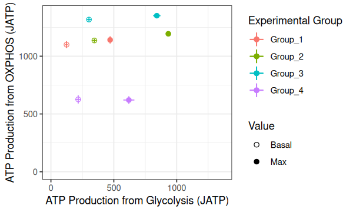

Bioenergetic scope with replicates combined

```r
bioscope <- bioscope_plot(
  energetics,
  model = "ols",
  sep_reps = FALSE
)
bioscope
```

#### Replicates as random effects

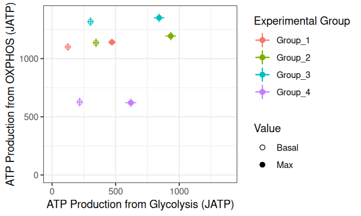

Bioenergetic scope based on a mixed-effects model with replicates as random effect

```r
bioscope_plot(energetics, sep_reps = FALSE, model = "mixed")
```

#### Replicates separated

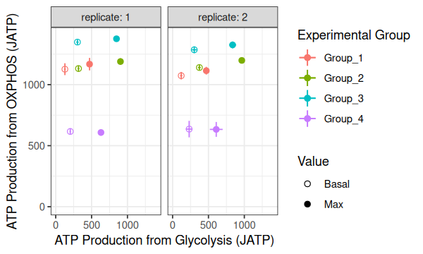

Bioenergetic scope with replicates separated

```r
bioscope_plot(energetics, sep_reps = TRUE, model = "ols")
```

### Rate plots

The `rate_plot` function provides an overview of OCR or ECAR for each assay type over time, which enables cross-group energetic comparisons before and after the addition of energetic-modulating compounds. The `rate_plot` line represents mean group OCR or ECAR over the sequential measurements (x-axis) and the shaded variance region represents standard deviation or specified confidence interval.

#### Oxygen consumption rate (OCR)

##### Replicates combined

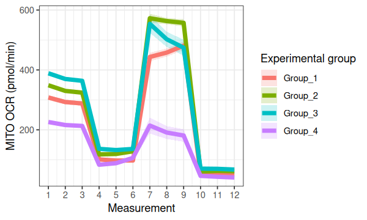

OCR with replicates combined

```r
ocr <- rate_plot(
  seahorse_rates,
  measure = "OCR",
  assay = "MITO",
  model = "ols",
  sep_reps = FALSE
)
ocr
```

##### Replicates as random effects

```
#> boundary (singular) fit: see help('isSingular')
#> boundary (singular) fit: see help('isSingular')
```

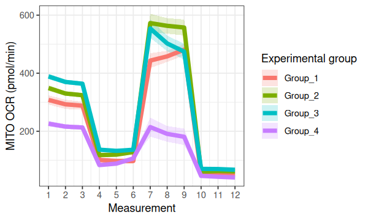

OCR based on mixed-effects model

```r
rate_plot(
  seahorse_rates,
  measure = "OCR",
  assay = "MITO",
  model = "mixed",
  sep_reps = FALSE
)
```

##### Replicates separated

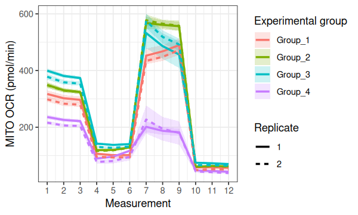

OCR with replicates separated

```r
rate_plot(
  seahorse_rates,
  measure = "OCR",
  assay = "MITO",
  model = "ols",
  sep_reps = TRUE,
  linewidth = 1
)
```

#### Extracellular Acidification Rate (ECAR)

##### Replicates combined

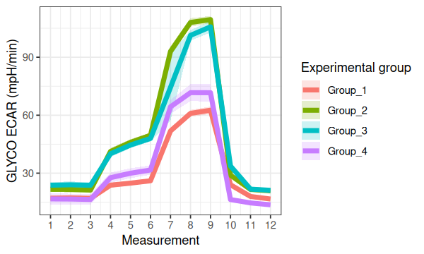

ECAR with replicates combined

```r
ecar <- rate_plot(
  seahorse_rates,
  measure = "ECAR",
  assay = "GLYCO",
  model = "ols",
  sep_reps = FALSE
)
ecar
```

##### Replicates as random effects

```
#> boundary (singular) fit: see help('isSingular')
#> boundary (singular) fit: see help('isSingular')
```

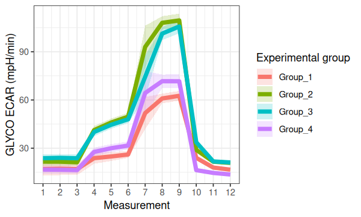

ECAR based on mixed-effects model

```r
rate_plot(
  seahorse_rates,
  measure = "ECAR",
  assay = "GLYCO",
  model = "mixed",
  sep_reps = FALSE
)
```

##### Replicates separated

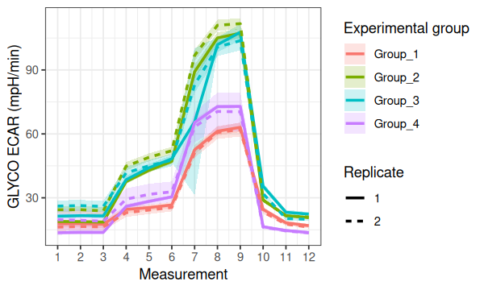

ECAR with replicates separated

```r
rate_plot(
  seahorse_rates,
  measure = "ECAR",
  assay = "GLYCO",
  model = "ols",
  sep_reps = TRUE,
  linewidth = 1

)
```

### ATP plots

The `atp_plot` function plots group JATP values, which enables cross-group OXPHOS and glycolytic JATP comparisons at basal and max conditions. The `atp_plot` symbols represent the mean basal or max JATP from OXPHOS or glycolysis, and the crossbar boundaries represent the standard deviation or confidence interval JATP variance.

#### Basal glycolysis

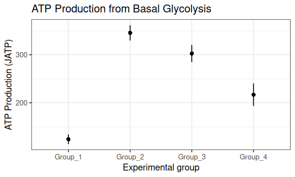

JATP from basal glycolysis with replicates combined

```r
basal_glyc <- atp_plot(
  energetics,
  basal_vs_max = "basal",
  glyc_vs_resp = "glyc",
  sep_reps = FALSE
)
basal_glyc
```

#### Basal respiration

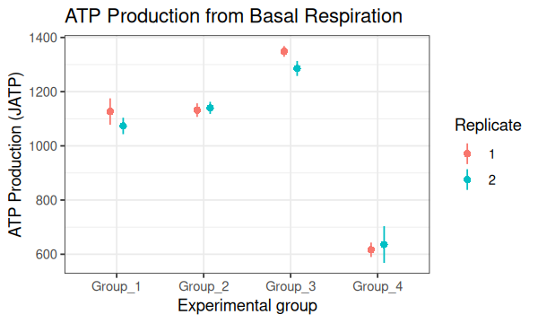

JATP from basal respiration with replicates separated

```r
atp_plot(
  energetics,
  basal_vs_max = "basal",
  glyc_vs_resp = "resp",
  model = "ols",
  sep_reps = TRUE
)
```

#### Maximal glycolysis

```
#> boundary (singular) fit: see help('isSingular')
```

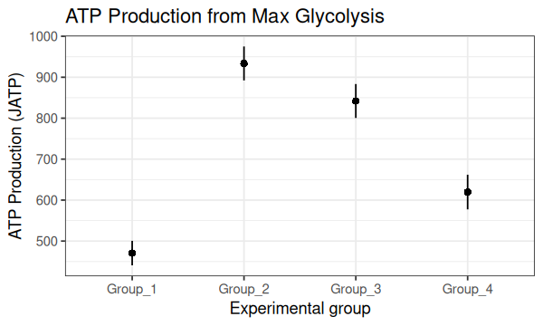

JATP from maximal glycolysis with a mixed-effects model

```r
atp_plot(
  energetics,
  basal_vs_max = "max",
  glyc_vs_resp = "glyc",
  model = "mixed",
  sep_reps = FALSE
)
```

#### Maximal respiration

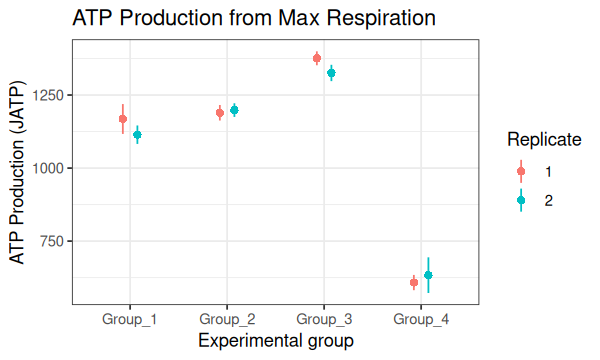

```r
atp_plot(
  energetics,
  basal_vs_max = "max",
  glyc_vs_resp = "resp",
  model = "ols",
  sep_reps = TRUE
)
```

### Customizing plots

CEAS is designed to work with existing `ggplot2` customization functionality and doesn’t include more than shape and size options for its plots.

For example, to change the colors used in the plot, simply make the plot and add the custom colors you’d like:

#### Colors

```r
custom_colors <- c("#e36500", "#b52356", "#3cb62d", "#328fe1")
```

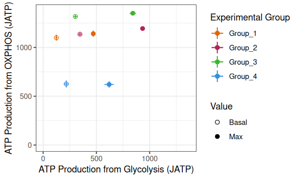

```r
bioscope +
ggplot2::scale_color_manual(
  values = custom_colors
)
```

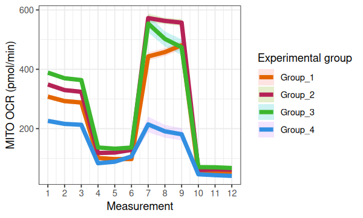

```r
ocr +
ggplot2::scale_color_manual(
  values = custom_colors
)
```

#### Labels

##### Change axis labels

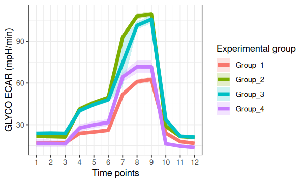

```r
ecar +
    ggplot2::labs(x = "Time points")
```

##### Change label size

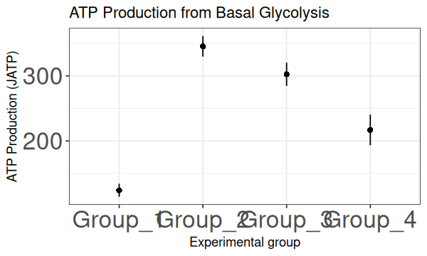

```r
basal_glyc +
    ggplot2::theme(axis.text = ggplot2::element_text(size = 20))
```

#### Editing functions

We are working on making the plots as customizable as possible. However, if there are options that cannot be set in the calls to the plotting functions or with `ggplot2` functions, you can get the code used to make the plots by running the function name without parenthesis and modify it. Further, since every step in the ceas workflow provides a dataset, you can run the modified function or your own custom plotting functions on those datasets.

```r
rate_plot
```

```r
function (seahorse_rates, measure = "OCR", assay = "MITO", model = "ols",
    error_bar = "ci", conf_int = 0.95, group_label = "Experimental group",
    linewidth = 2, sep_reps = FALSE, ci_method = "Wald")
{
    stopifnot(`'measure' should be 'OCR' or 'ECAR'` = measure %in%
        c("OCR", "ECAR"))
    stopifnot(`'model' should be 'ols' or 'mixed'` = model %in%
        c("ols", "mixed"))
    stopifnot(`cannot run mixed-effects model with \`sep_reps = TRUE\`` = (model ==
        "mixed" & !sep_reps) | (model == "ols"))
    stopifnot(`'error_bar' should be 'sd' or 'ci'` = error_bar %in%
        c("sd", "ci"))
    stopifnot(`'conf_int' should be between 0 and 1` = conf_int >
        0 && conf_int < 1)
    data_cols <- c("Measurement", "Well", "OCR", "ECAR", "PER",
        "exp_group", "assay_type", "replicate")
    missing_cols <- setdiff(data_cols, colnames(seahorse_rates))
    if (length(missing_cols) != 0) {
        stop(paste0("'", missing_cols, "'", " column was not found in input data\n"))
    }
    Measurement <- NULL
    exp_group <- NULL
    lower_bound <- NULL
    upper_bound <- NULL
    multi_rep <- length(unique(seahorse_rates$replicate)) > 1
    if (!sep_reps && missing(sep_reps) && multi_rep)
        warning(sep_reps_warning)
    plot_data <- get_rate_summary(seahorse_rates, measure, assay,
        model, error_bar, conf_int, sep_reps)
    y_labels <- list(OCR = paste0(assay, " OCR (pmol/min)"),
        ECAR = paste0(assay, " ECAR (mpH/min)"))
    p <- ggplot(plot_data, aes(x = Measurement, y = mean, color = exp_group,
        group = if (sep_reps && multi_rep)
            interaction(exp_group, replicate)
        else exp_group, fill = exp_group)) + geom_ribbon(aes(ymin = lower_bound,
        ymax = upper_bound), alpha = 0.2, color = NA) + scale_x_continuous(breaks = seq(1,
        12, by = 1)) + xlab("Measurement") + ylab(y_labels[measure]) +
        labs(color = group_label, fill = group_label, linetype = "Replicate") +
        theme_bw()
    if (sep_reps && multi_rep) {
        p + geom_line(aes(linetype = replicate), linewidth = linewidth)
    }
    else {
        p + geom_line(linewidth = linewidth)
    }
}
```

In RStudio, you can run `utils::edit` to modify a function.

```r
edit(rate_plot)
```

## References

Mookerjee, Shona A., Akos A. Gerencser, David G. Nicholls, and Martin D. Brand. 2017. “Quantifying Intracellular Rates of Glycolytic and Oxidative ATP Production and Consumption Using Extracellular Flux Measurements.” *Journal of Biological Chemistry* 292 (17): 7189–7207. https://doi.org/10.1074/jbc.M116.774471.